# Lab03 - Dungeness Crab Growth

Jonathan Stuart

5/1/2018

### Problem 1

```r
#exploring the data - crab_molt
names(crab_molt)
```

```
## [1] "presz"  "postsz" "inc"    "year"   "lf"
```

```r
str(crab_molt)
```

```
## 'data.frame':    472 obs. of  5 variables:
##  $ presz : num  114 118 120 126 127 ...
##  $ postsz: num  128 133 135 143 139 ...
##  $ inc   : num  14.1 15.1 15.4 17.1 12.6 12.9 15.6 15.1 17.1 13.2 ...
##  $ year  : int  NA NA NA NA NA NA NA NA NA NA ...
##  $ lf    : int  0 0 0 0 0 0 0 0 0 0 ...
```

```r
head(crab_molt)
```

```
##   presz postsz  inc year lf
## 1 113.6  127.7 14.1   NA  0
## 2 118.1  133.2 15.1   NA  0
## 3 119.9  135.3 15.4   NA  0
## 4 126.2  143.3 17.1   NA  0
## 5 126.7  139.3 12.6   NA  0
## 6 127.3  140.2 12.9   NA  0
```

```r
#exploring the data - crab_pop
names(crab_pop)
```

```
## [1] "size"  "shell"
```

```r
str(crab_pop)
```

```
## 'data.frame':    362 obs. of  2 variables:
##  $ size : num  117 117 118 120 120 ...
##  $ shell: int  1 1 1 1 1 1 1 1 1 1 ...
```

```r
head(crab_pop)
```

```
##    size shell
## 1 116.8     1
## 2 117.1     1
## 3 118.4     1
## 4 119.6     1
## 5 120.1     1
## 6 120.4     1
```

**Analysis by Year**

```
## year
##  81  82  92
##  68 115 178
```

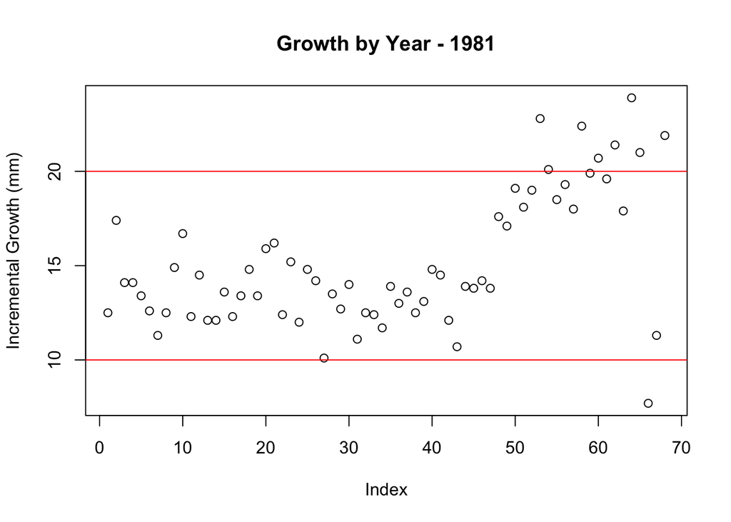

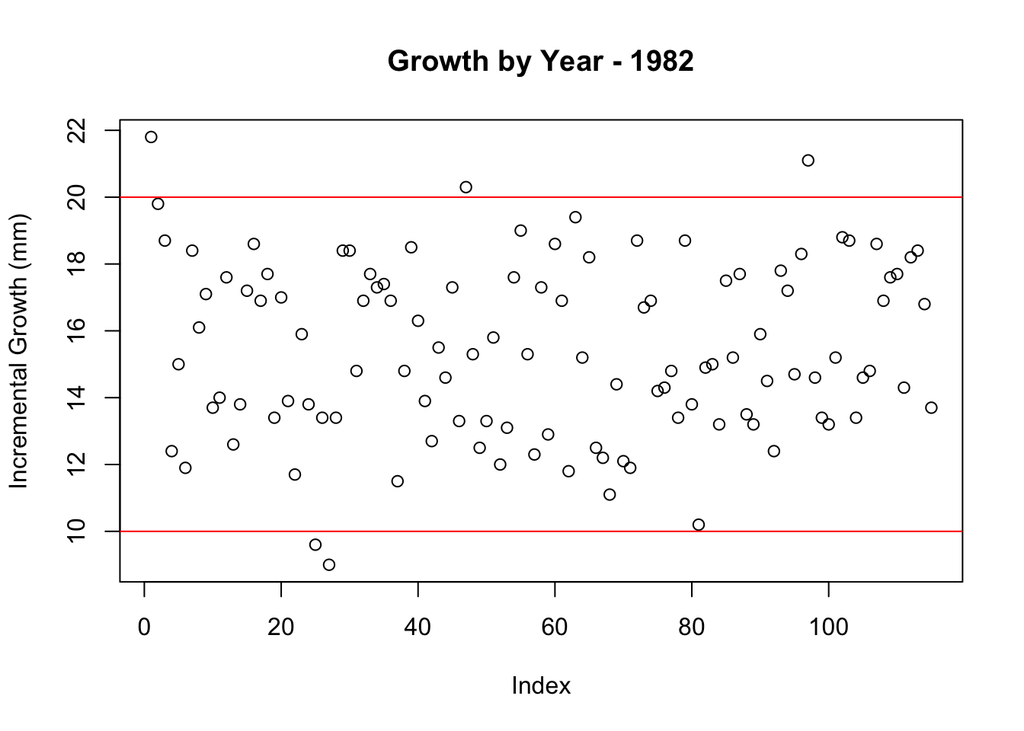

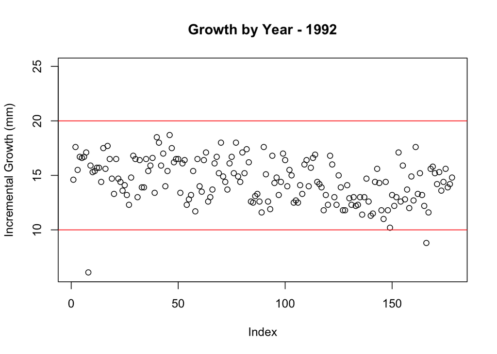

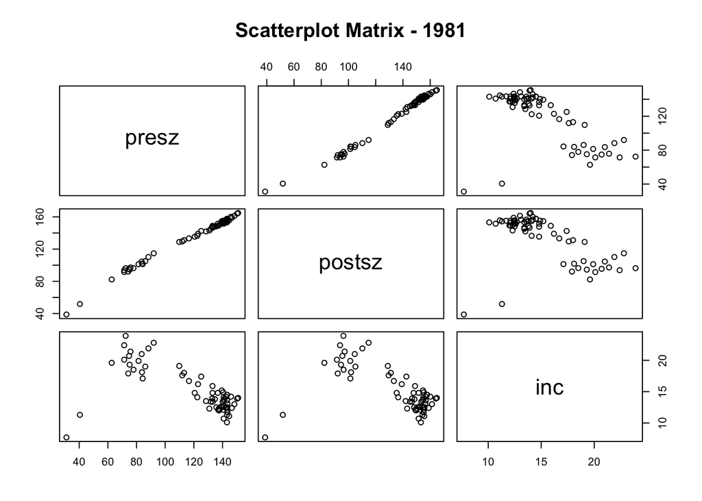

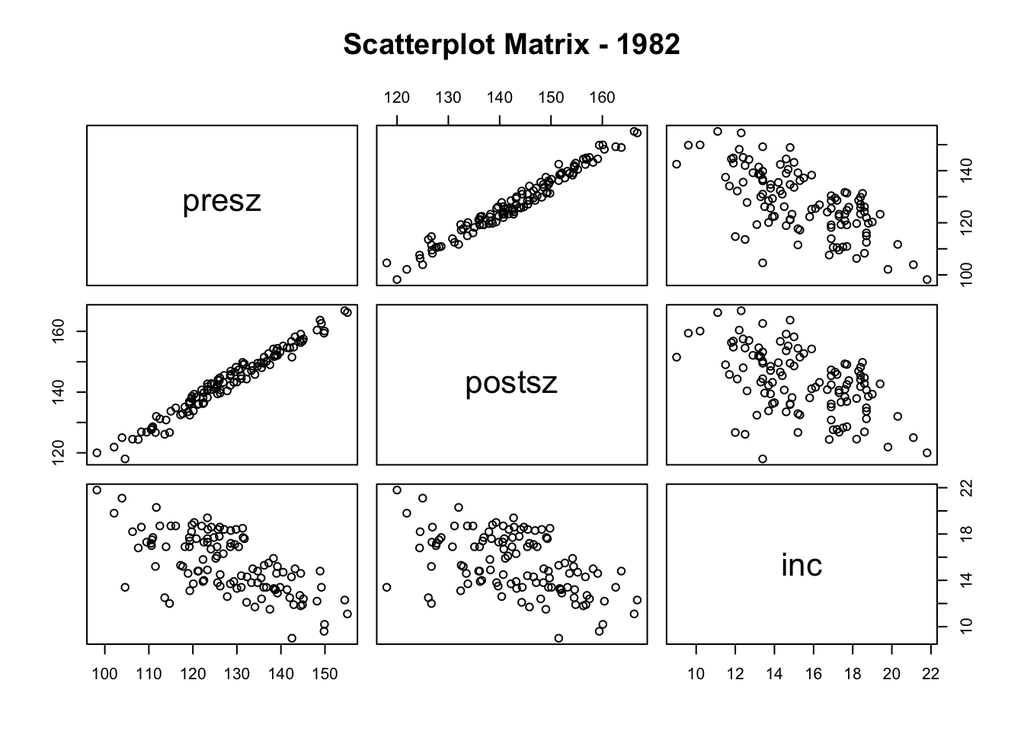

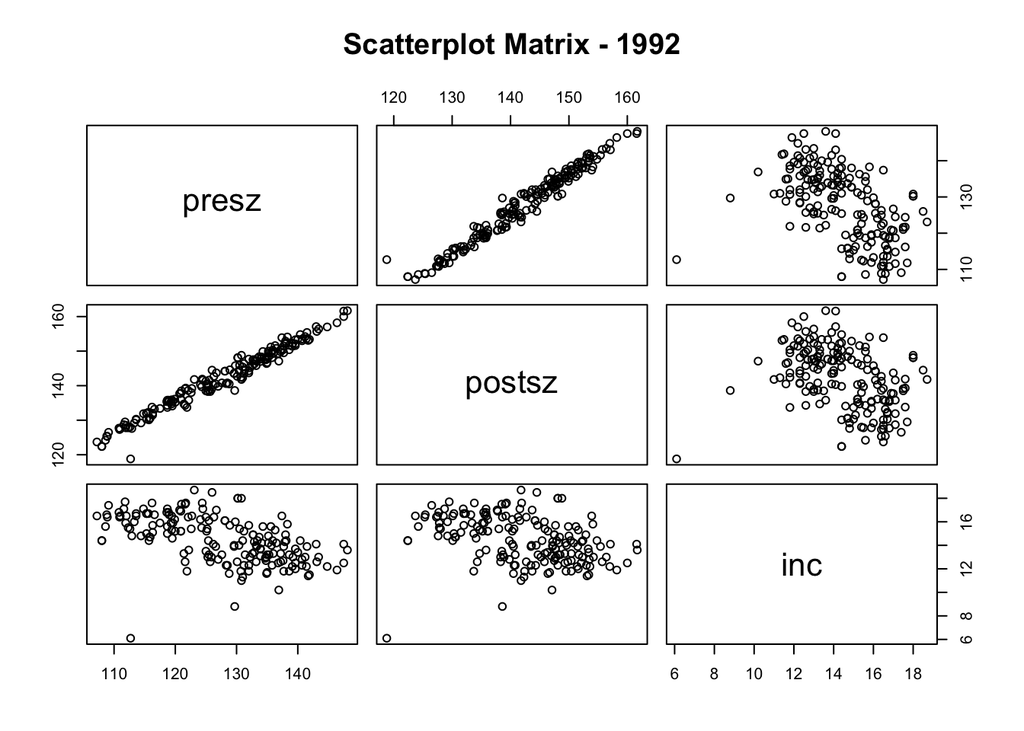

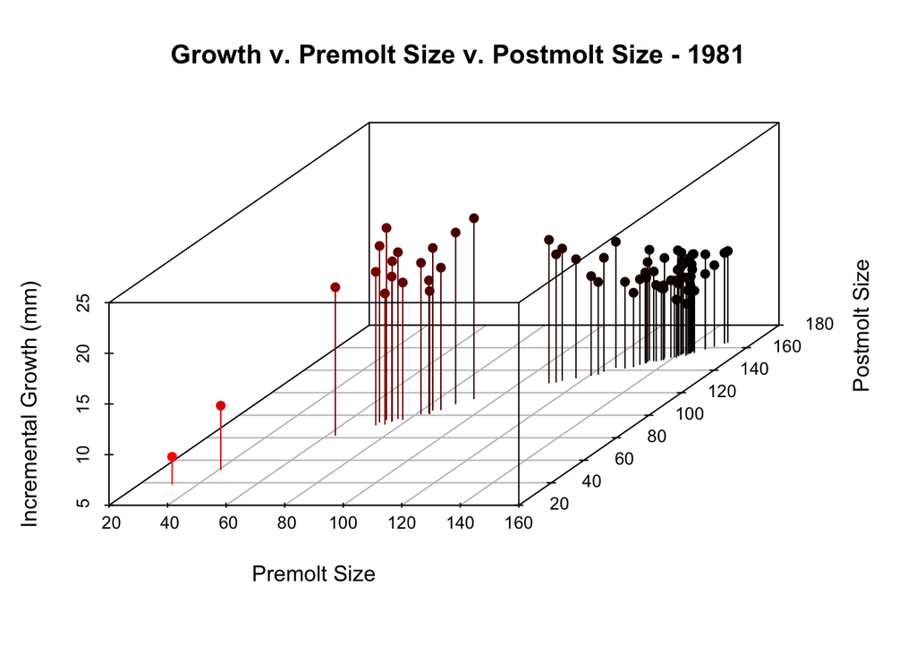

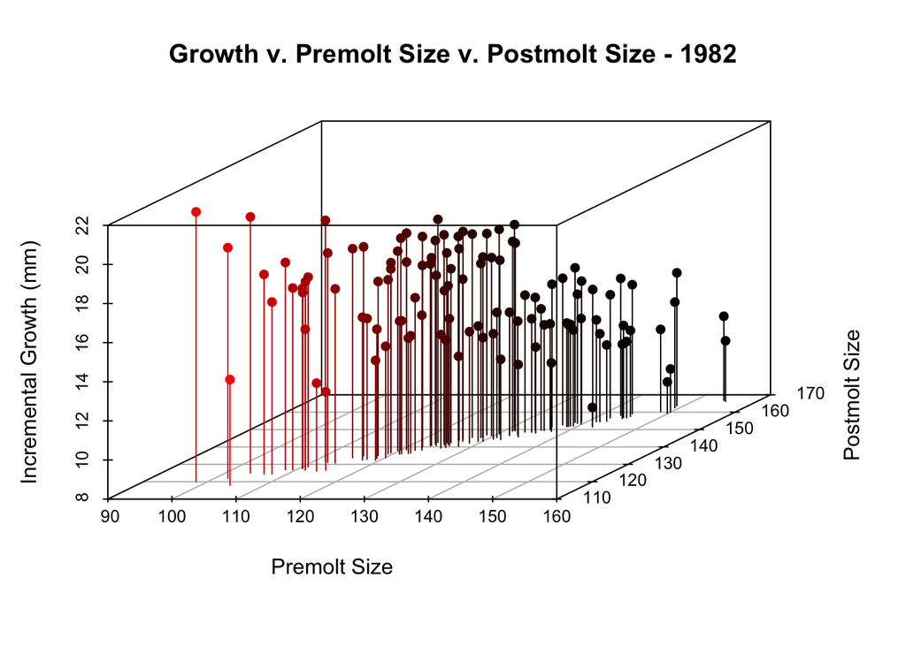

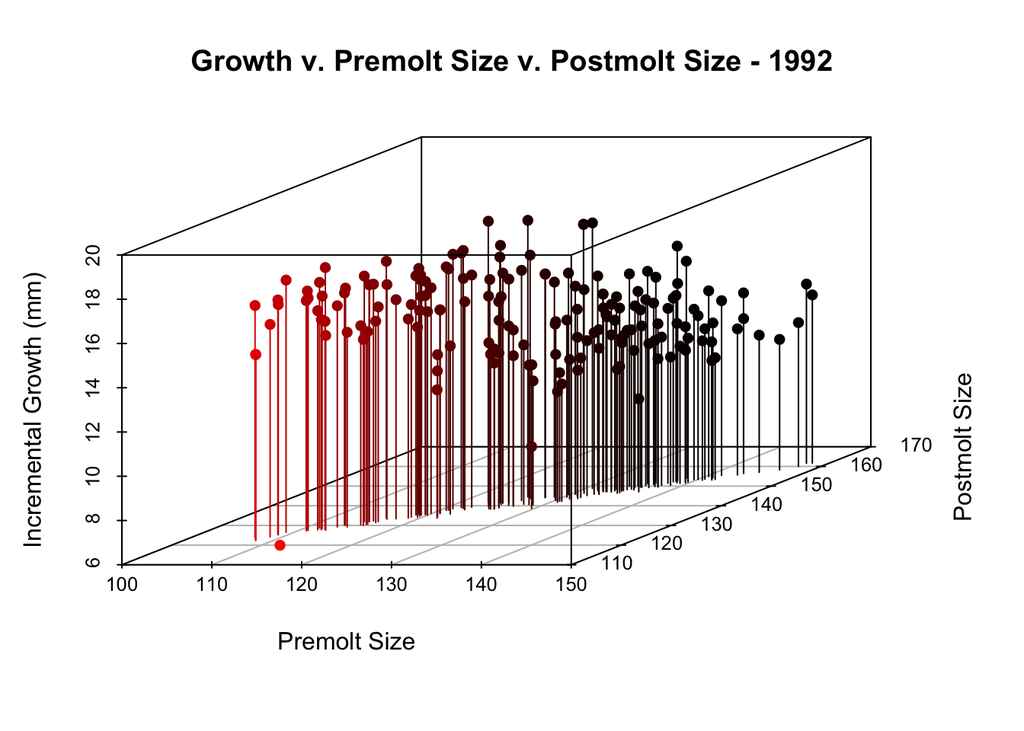

**Analysis by Obervation Method**  
*Summarize one relevant variable using numbers and words*

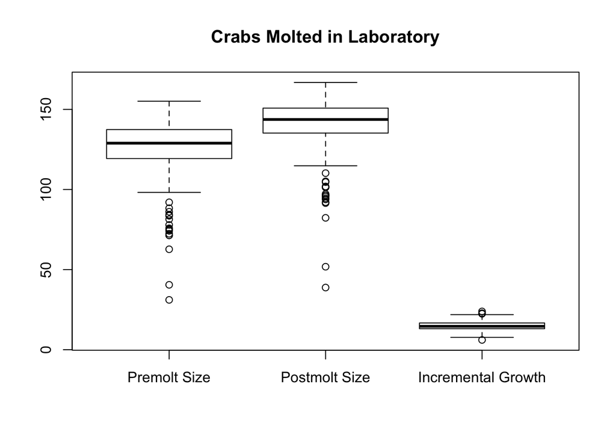

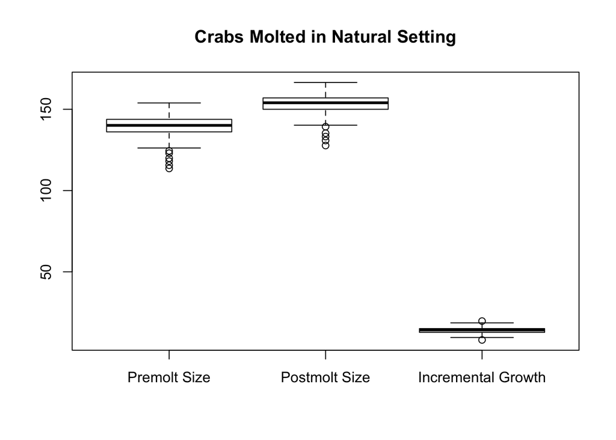

In the boxplots above, we see that the data from the crabs molting in the laboratory had far more outlying values than the data from the crabs that molted in a natural setting. Also notable is the range of values indicated for all three variables. For both the pre and post molt sizes of the crabs that molted in a natural setting, we see a range of approximately 25 mm. For both the pre and post molt sizes of the crabs that molted in the laboratory, however, we see a range of approximately 50 mm. The incremental growth statistics between those crabs that molted in both the natural and laboratory settings appear to be quite near each other, with the larger increments being recorded for the laboratory crabs. This last point is notable as it contradicts what we would expect to see, given Nolan/Speed’s comments that “crabs in captivity have smaller molt increments than those in the wild.”[*Stat Labs*, Nolan, Speed. Pg 143]

Numerical summary of crabs molted in laboratory.

```r
summary(lab[1:3])
```

```
##      presz           postsz           inc
##  Min.   : 31.1   Min.   : 38.8   Min.   : 6.10
##  1st Qu.:119.3   1st Qu.:135.2   1st Qu.:13.10
##  Median :128.9   Median :143.7   Median :14.60
##  Mean   :126.2   Mean   :141.1   Mean   :14.91
##  3rd Qu.:137.4   3rd Qu.:150.8   3rd Qu.:16.70
##  Max.   :155.1   Max.   :166.8   Max.   :23.90
```

Numerical summary of crabs molted in a natural setting.

```r
summary(wild[1:3])
```

```
##      presz           postsz           inc
##  Min.   :113.6   Min.   :127.7   Min.   : 8.10
##  1st Qu.:136.1   1st Qu.:150.0   1st Qu.:12.75
##  Median :140.1   Median :154.0   Median :14.20
##  Mean   :139.0   Mean   :153.0   Mean   :13.95
##  3rd Qu.:143.8   3rd Qu.:157.0   3rd Qu.:15.10
##  Max.   :153.9   Max.   :166.5   Max.   :19.70
```

### Problem 2

```r
#building a regression model (least squares)
#pg 147

#y
response <- crab_molt['presz']
response <- unlist(response)

#x
predictor <- crab_molt['postsz']
predictor <- unlist(predictor)

#calculating the correlation coefficient
corr_coef <- sum((((predictor - mean(predictor)) / sd(predictor)) * ((response - mean(response)) / sd(response)))) / length(predictor)

corr_coef_function <- cor(predictor, response)

#calculating beta_hat_1 using correlation coefficient
beta_hat_1_a <- corr_coef * (sd(response) / sd(predictor))

#calculating beta_hat_1 without correlation coefficient
beta_hat_1_b <- sum(((predictor - mean(predictor)) * (response - mean(response)))) / sum((predictor - mean(predictor))^2)

#calculating beta_hat_0_a
beta_hat_0_a <- mean(response) - beta_hat_1_a * mean(predictor)

#calculating beta_hat_0_b
beta_hat_0_b <- mean(response) - beta_hat_1_b * mean(predictor)

#linear regression model
regression <- function(x){
  beta_hat_0_a + beta_hat_1_a * x
}
```

### Problem 3

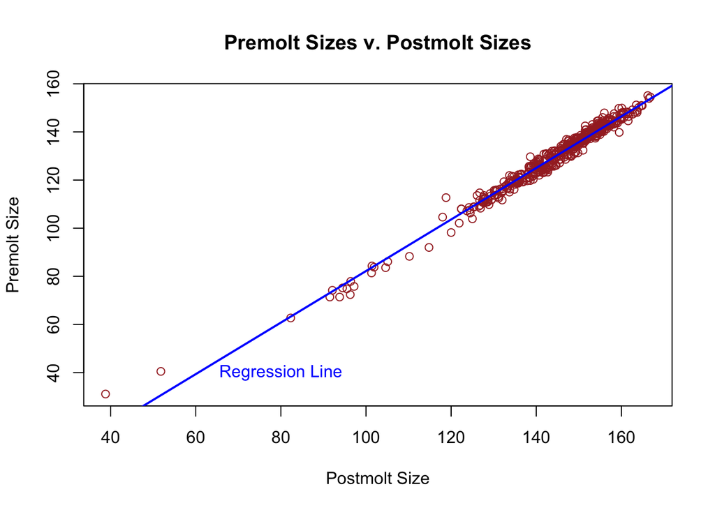

### Problem 4

*What is your interpretation of this regression line?*  
This is the line that minimizes the squared distances between itself and each data point. Plainly put, it is the line that best fits the data. Along the regression line, each data point’s squared distance from it is minimized.

*What percent of the variation of the premolt sizes is explained by the model?*  
The proportion of variation explained by the regression line is captured by the *coefficient of determination,* $r^2$. It is a measure of how well the variation in one variable explains the variation in another variable. In this case, the percentage of variation $r^2$ is

```
## [1] 97.66809
```

The higher the value of $r^2$ (maximum +/- 100% as a percentage), the more confidently we can rely on the regression line to make accurate predictions.

### Problem 5

According to Nolan and Speed, “[t]he residual is a name for the difference between a crab’s actual premolt size and the regression line prediction of it.”[*Stat Labs*, Nolan, Speed. Pg 148]

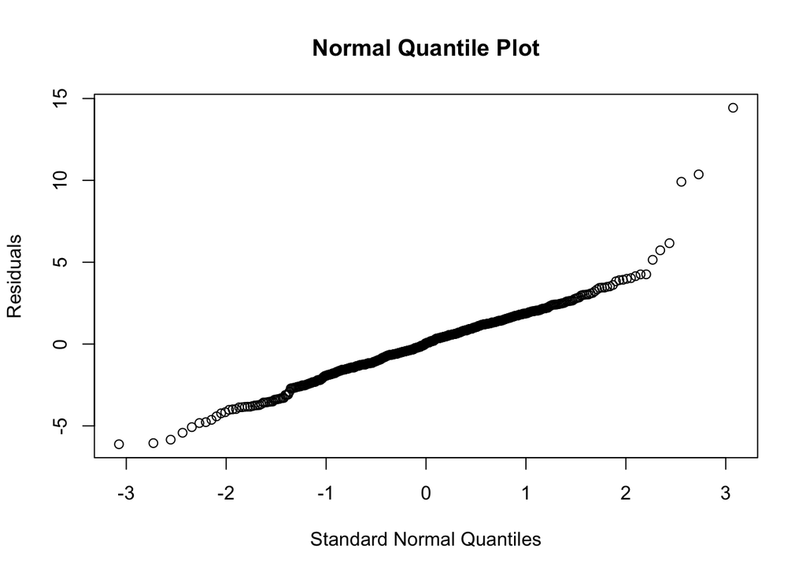

We see that the normal quantile-quantile plot follows nearly a straight line, indicating that the residuals are approximately normally distributed.

### Problem 6

According to Rice, for large values of $n$, the estimated slope and intercept of a linear regression model are approximately normally distributed. This is due to the fact that if the terms representing random noise are independent and the predictor values are well-behaved, then a version of the central limit theorem applies for large $n$.[*Mathematical Statistics and Data Analysis*, Rice. Pg 549-550] Hypothesis tests can then be carried out using the following as a t-test test statistic:

$\frac{{\hat\beta}_{i} - \beta_{i}}{s_{\hat\beta_{i}}}$,

where the ${s_{\hat\beta_{i}}}$ are the estimated standard errors of ${\hat\beta}_{0}$ and ${\hat\beta}_{1}$.

```r
#Test the null hypothesis that the postmolt size has no predictive value
s_squared <- sum(residuals^2)/(length(crab_molt$presz)-2)

s_beta_0_a_squared <- (s_squared * sum(crab_molt$postsz^2)) / ((length(crab_molt$postsz) * sum((crab_molt$postsz^2))) - (sum(crab_molt$postsz))^2)

s_beta_1_a_squared <- (length(crab_molt$postsz) * s_squared) / ((length(crab_molt$postsz) * sum((crab_molt$postsz^2))) - (sum(crab_molt$postsz))^2)

#beta_0 t-test statistic
beta_hat_0_a / sqrt(s_beta_0_a_squared)
```

```
## [1] -24.86156
```

```r
#Beta_1 t-test statistic
beta_hat_1_a / sqrt(s_beta_1_a_squared)
```

```
## [1] 154.7368
```

```
## [1] 2.191174e-16
```

and

```
## [1] 3.867358e-32
```

### Problem 7

```r
#dropping juvenile crabs, creating new linear model
mature_crab_molt <- filter(crab_molt, presz >= 100)

#y
mature_response <- mature_crab_molt['presz']
mature_response <- unlist(mature_response)

#x
mature_predictor <- mature_crab_molt['postsz']
mature_predictor <- unlist(mature_predictor)

#calculating the correlation coefficient
mature_corr_coef <- sum((((mature_predictor - mean(mature_predictor)) / sd(mature_predictor)) * ((mature_response - mean(mature_response)) / sd(mature_response)))) / length(mature_predictor)

mature_corr_coef_function <- cor(mature_predictor, mature_response)

#calculating beta_hat_1 using correlation coefficient
mature_beta_hat_1_a <- mature_corr_coef * (sd(mature_response) / sd(mature_predictor))

#calculating beta_hat_1 without correlation coefficient
mature_beta_hat_1_b <- sum(((mature_predictor - mean(mature_predictor)) * (mature_response - mean(mature_response)))) / sum((mature_predictor - mean(mature_predictor))^2)

#calculating beta_hat_0_a
mature_beta_hat_0_a <- mean(mature_response) - mature_beta_hat_1_a * mean(mature_predictor)

#calculating beta_hat_0_b
mature_beta_hat_0_b <- mean(mature_response) - mature_beta_hat_1_b * mean(mature_predictor)

#linear regression model
mature_regression <- function(x){
  mature_beta_hat_0 + mature_beta_hat_1_a * x
}
```

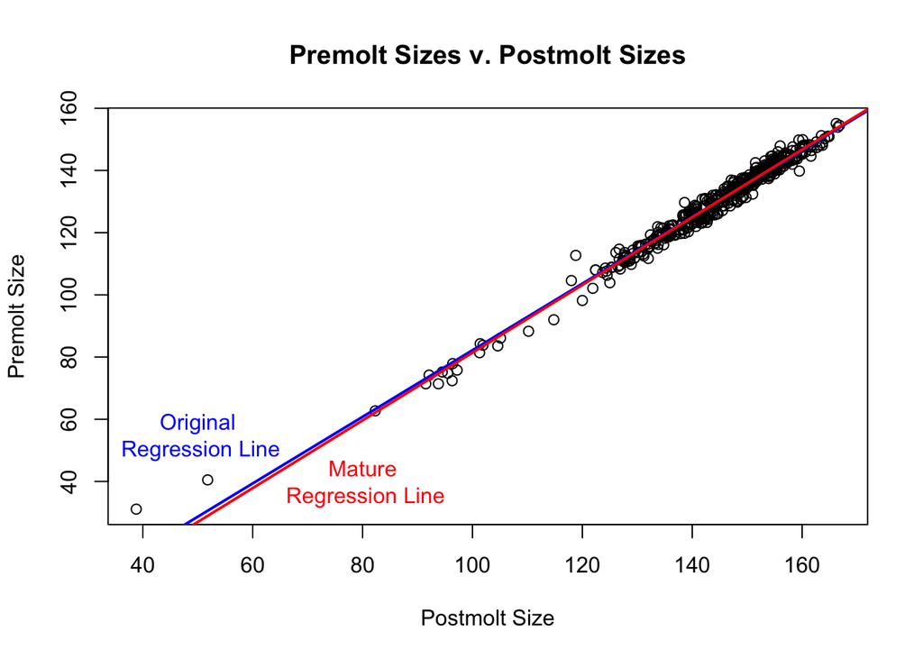

### Problem 8

Using the postmolt size of the molted crabs collected immediately following the 1983 molting season, we use the regression method developed in **Problem 2** to predict the premolt sizes of the crabs collected.

```r
#running the regression on crab_pop and analyzing
molted_crabs <- group_by(crab_pop, shell)
molted_crabs_regression <- regression(molted_crabs[ , 1])
molted_crabs <- as.data.frame(molted_crabs)
molted_crabs$regression <- molted_crabs_regression
```

Here we have a summary of the premolt size data, obtained through regression, and the requested histogram.

```
##       size
##  Min.   : 77.28
##  1st Qu.:123.65
##  Median :132.59
##  Mean   :130.63
##  3rd Qu.:140.24
##  Max.   :155.02
```

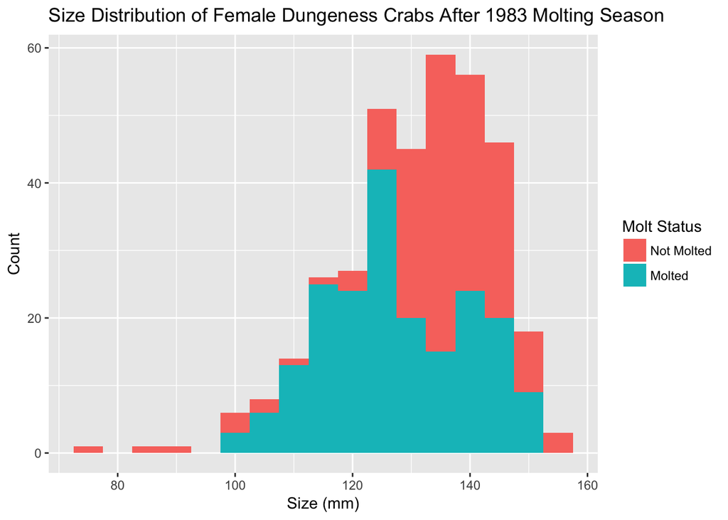